# A4 Summary

```r
library(tidyverse)
```

```r
library(dplyr)
library(ggplot2)
library(maps)
## read in the data
data_link <- "https://raw.githubusercontent.com/melaniewalsh/Neat-Datasets/main/us-prison-pop.csv"
inc_data <- read.csv(data_link, stringsAsFactors = FALSE)

## smaller dataset with just the information we need - prison population m/f and totals
## omitted na values to make it easier later
prison_data <- inc_data %>% select(male_prison_pop, female_prison_pop, total_prison_pop, year, state)
prison_data <- na.omit(prison_data)
```

### Introduction

For this project I decided to analyze the Female and Male Prison populations. Yes this is slightly different than analyzing by race, but understanding differences in populations by sex is equally as important as by race in order to understand the entire social picture and it was a subject that peaked my interest. I began running some simple statistics on them such as the change in Prisoners per year for each population and the average change per year. One thing I noticed initially about the overall male and female prisoner populations is the vast difference in numbers between the two. The male population of prisoners is almost 10x that of the female prisoner population. I wanted to find a way to compare statistics between the two about change in population size so I decided to run the calculations based on percent increase rather than the raw numbers themselves.

This study is important because it allows comparison between the male and female prison populations. It could be useful to monitor how these populations change to watch for abnormalities, correlations, and differences in behavior of the population as a whole. For example, if there was an event during a certain year that pertained more to one sex (for example a Me Too movement or a draft), analyzing the differences between populations could lead to findings that tell about the social atmosphere of that time. Perhaps there was a sharp increase/decrease in the female prison population after that year which could lead to more research around what could have caused a sharp jump not seen in the male prison population.

### Summary Statistics

How many Female Prisoners got admitted in the most recent year data was collected (2016)?

```r
## run statistics
## how many female prisoners got admitted this year?
current_fem_prisoners <- prison_data %>% filter(year == max(year)) %>% pull(female_prison_pop)
current_fem_prisoners <- sum(current_fem_prisoners)
last_yr_fem_prisoners <- prison_data %>% filter(year == max(year) - 1) %>% pull(female_prison_pop)
last_yr_fem_prisoners <- sum(last_yr_fem_prisoners)
print(current_fem_prisoners - last_yr_fem_prisoners)
```

```
## [1] -1820
```

how many male?

```r
current_male_prisoners <- prison_data %>% filter(year == max(year)) %>% pull(male_prison_pop)
current_male_prisoners <- sum(current_male_prisoners)
last_yr_male_prisoners <- prison_data %>% filter(year == max(year) - 1) %>% pull(male_prison_pop)
last_yr_male_prisoners <- sum(last_yr_male_prisoners)
print(current_male_prisoners - last_yr_male_prisoners)
```

```
## [1] -40885
```

how many female/male prisoners were added each year? what % increase/decrease did this represent? those values were added in new columns in the dataset the mean number of new prisoners added each year is printed for Female and Male populations

```r
## set up a data set with each year and total prisoners for each pop
sum_prison_data <- prison_data %>% group_by(year) %>% summarise(female_prison_pop = sum(female_prison_pop), male_prison_pop = sum(male_prison_pop), total_prison_pop = sum(total_prison_pop))

## new columns with new prisoners each year
sum_prison_data <- sum_prison_data %>% mutate(new_fem_prisoners = female_prison_pop - lag(female_prison_pop, n = 1, default = 0))
## run some stats about the new column
mean_new_fem_prisoners <- mean(sum_prison_data$new_fem_prisoners)
print(mean_new_fem_prisoners)
```

```
## [1] 1642.702
```

```r
## percent increase column
sum_prison_data <- sum_prison_data %>% mutate(percent_inc_fem = new_fem_prisoners / female_prison_pop, n = 1, default = 0)

## new prisoner column for male
sum_prison_data <- sum_prison_data %>% mutate(new_male_prisoners = male_prison_pop - lag(male_prison_pop, n = 1, default = 0))
## run som stats about the new column
mean_new_male_prisoners <- mean(sum_prison_data$new_male_prisoners)
print(mean_new_male_prisoners)
```

```
## [1] 20340.04
```

```r
## percent increase column
sum_prison_data <- sum_prison_data %>% mutate(percent_inc_male = new_male_prisoners / male_prison_pop, n = 1, default = 0)
```

what about the total?

```r
## total stats
sum_prison_data <- sum_prison_data %>% mutate(new_total_prisoners = total_prison_pop - lag(total_prison_pop, n = 1, default = 0))
## run som stats about the new column
mean_new_total_prisoners <- mean(sum_prison_data$new_total_prisoners)
print(mean_new_total_prisoners)
```

```
## [1] 21983.68
```

```r
## percent increase column
sum_prison_data <- sum_prison_data %>% mutate(percent_inc_total = new_total_prisoners / total_prison_pop, n = 1, default = 0)
```

whats the most Female prisoners admitted in one year and what was the year?

```r
most_fem <- max(sum_prison_data$new_fem_prisoners)
## most Female Prisoners Admitted
print(most_fem)
```

```
## [1] 15604
```

```r
most_fem_year <- sum_prison_data %>% filter(new_fem_prisoners == max(new_fem_prisoners)) %>% pull(year)
## the Year
print(most_fem_year)
```

```
## [1] 2005
```

whats about for men?

```r
most_men <- max(sum_prison_data$new_male_prisoners)
## most Female Prisoners Admitted
print(most_men)
```

```
## [1] 213665
```

```r
most_men_year <- sum_prison_data %>% filter(new_male_prisoners == max(new_male_prisoners)) %>% pull(year)
## the Year
print(most_men_year)
```

```
## [1] 1983
```

What year did the total amount of prisoners decrease the most and what year?

```r
least_total <- min(sum_prison_data$new_total_prisoners, na.rm = TRUE)
## most Female Prisoners Admitted
print(least_total)
```

```
## [1] -80329
```

```r
least_total_year <- sum_prison_data %>% filter(new_total_prisoners == min(new_total_prisoners, na.rm = TRUE)) %>% pull(year)
## the Year
print(least_total_year)
```

```
## [1] 2015
```

### The Dataset

Who collected the data?  
Vera Institute of Justice

How was the data collected or generated? Collected from the BJS Census of Jails

Why was the data collected?  
The data was collected and made public in an effort to help educate about and end over-criminalization and mass incarceration of groups such as people who live in poverty and people of color. The Vera Institute does a lot of projects around issues relating to their cause and helps fund/start up programs designed to help. This data collection was one of their many projects to help educate and raise awareness about their cause and they created a tool on their website where it can be used to show statistics about incarceration by state.

How many observations (rows) are in your data?

```r
print(nrow(inc_data))
```

```
## [1] 153811
```

How many features (columns) are in the data?

```r
print(ncol(inc_data))
```

```
## [1] 36
```

What, if any, ethical questions or questions of power do you need to consider when working with this data? When working with mass data that is reported like this there is always a question of how accurate the data is based on who measured it etc. The counts of population by gender in prison could be off depending on the accuracy of their collection or could be influenced by the motives of the Prison / people involved with the prison. This could be affected by the State reporting it and political motives behind that State. There are also questions of the Vera Institute, it’s goals and agenda and where its funding comes from could all affect how this data is measured and what conclusions it supports. There could also be ethical questions surrounding how the racial data was collected. Was it self reported race or on a legal document? Were some people able to opt out of the data collection or omitted and how does that effect the results?

What are possible limitations or problems with this data? (at least 200 words) One of the biggest limitations with this data set is that most columns do not have data for a large percent of the rows. This makes it difficult to analyze between any column because of the amount of missing data. While there is still enough data to run analysis, especially when combining information by state or year, there are large gaps in information. For example the amount of entries per State is not equal. If there were more reports in one state, lets say Texas for example, and less reports in another state like Ohio, it could appear that there are far more Prisoners in Texas than Ohio when in reality the data wasn’t collected equally. After analysis, there are states such as Texas and California that have a much higher Prison population that otehr states by a lot – and it could be useful to measure how many entries were made for these states comapred to the otehrs. The same issue comes when grouping the data by year. Some years have far more entries than others making the data less reliable and harder to work with. There are a lot of NA values as well which need to be omitted to run a lot of basic statistics in R meaning that a lot of the time new data sets need to be created as a subset of the data that exclude NA values and are missing a lot of information. This is a similar problem to the first one only this one is relating to the functionality of R and not just statistics in general.

### Trends Over Time Chart

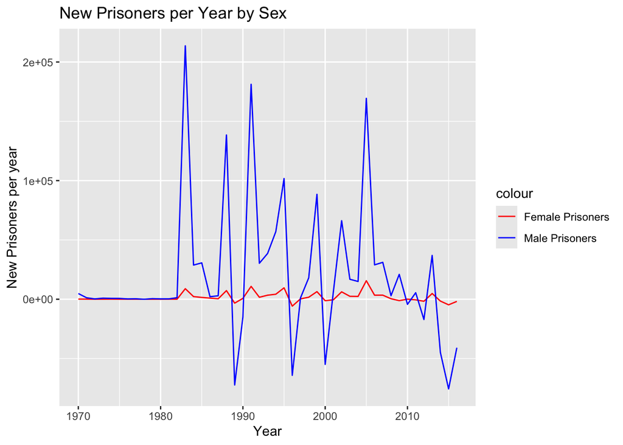

```r
ggplot(data = sum_prison_data, aes(x = year)) +
  geom_line(aes(y = new_fem_prisoners, color = "Female Prisoners")) +
  geom_line(aes(y = new_male_prisoners, color = "Male Prisoners")) +
  scale_color_manual(values = c("Female Prisoners" = "red", "Male Prisoners" = "blue")) +
  xlab("Year") +
  ylab("New Prisoners per year") +
  ggtitle("New Prisoners per Year by Sex")
```

This Chart shows the New Female/Male Prisoners admitted per year. I included this chart because it shows how much larger and how much more variation the Male Prisoner population has vs the Female Prisoner Population. It also shows how difficult it is to compare trends between 2 populations of vastly different sizes which I combat later in this report.

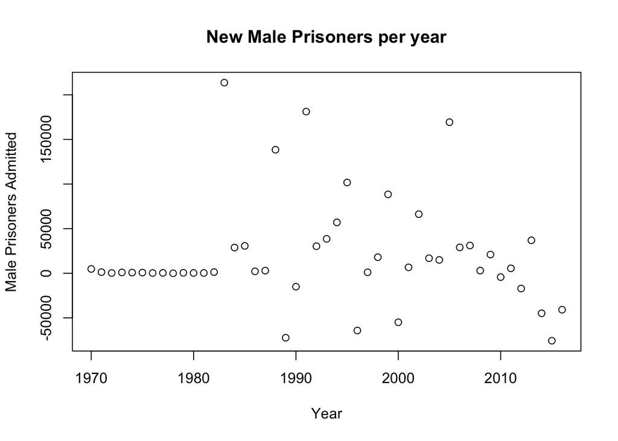

```r
plot(sum_prison_data$new_male_prisoners~sum_prison_data$year, main='New Male Prisoners per year', xlab='Year', ylab='Male Prisoners Admitted')
```

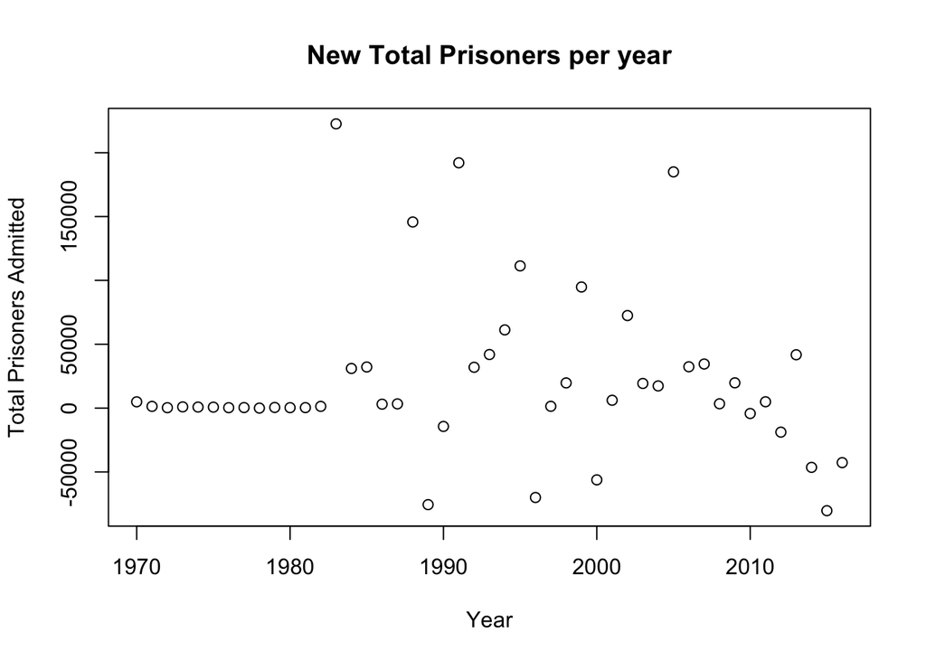

```r
plot(sum_prison_data$new_total_prisoners~sum_prison_data$year, main='New Total Prisoners per year', xlab='Year', ylab='Total Prisoners Admitted')
```

This chart shows a trend closest to the Male Total Prisoners chart and demonstrates why it’s important to separate the two populations to run statistics / analyze. The female population trends are completely overrun and impossible to measure in this overall chart.

### Variable Comparison Chart

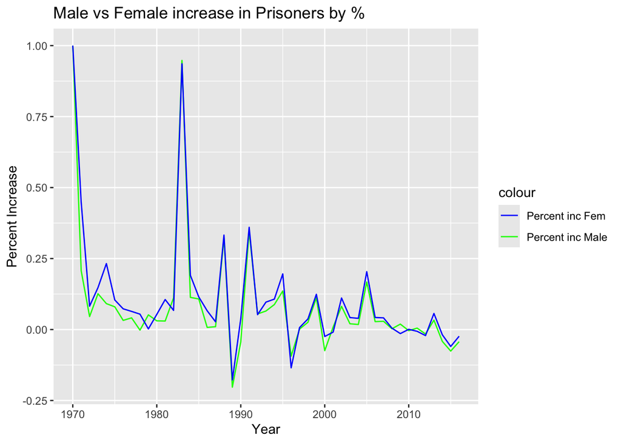

```r
## comparative chart using layers in ggplot

comparative_graph <- ggplot(sum_prison_data, aes(x = year)) +
  geom_line(aes(y = percent_inc_male, color = "Percent inc Male")) +
  geom_line(aes(y = percent_inc_fem, color = "Percent inc Fem")) +
  scale_color_manual(values = c("Percent inc Fem" = "blue", "Percent inc Male" = "green")) +
  labs(title="Male vs Female increase in Prisoners by %", x='Year', y='Percent Increase')

print(comparative_graph)
```

### Map

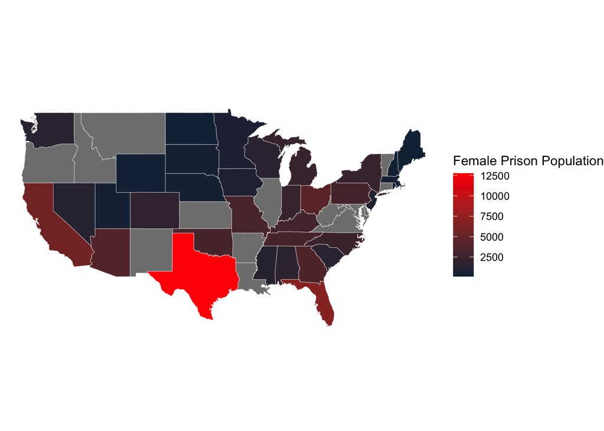

```r
## setting up a dataset with the state and m/f/t populations
current_year_data <- prison_data %>% filter(year == max(year)) %>% group_by(state) %>% summarise(female_prison_pop = sum(female_prison_pop), male_prison_pop = sum(male_prison_pop), total_prison_pop = sum(total_prison_pop))
## join the dataset to state map

## change abbreviations to full state names so it can be joined
current_year_data$state <- state.name[match(current_year_data$state, state.abb)]
current_year_data <- current_year_data %>% mutate(state = tolower(state))
state_shape <- map_data("state") %>% rename(state = region) %>% left_join(current_year_data, by="state")

## map 1: female prisoner population in 2016
ggplot(state_shape) +
  geom_polygon(
    mapping = aes(x = long, y = lat, group = group, fill = female_prison_pop),  # Use column names directly
    color = "white",  # Specify color (if needed)
    size = 0.1  # Specify size (if needed)
  ) +
  coord_map() +
  scale_fill_continuous(low = "#132B43", high = "Red") +
  labs(fill = "Female Prison Population") +
  theme_void()
```

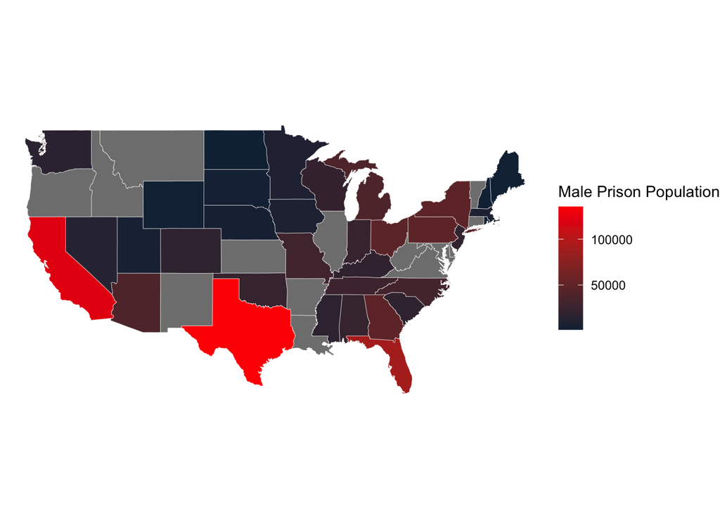

```r
## map 2: Male prisoner population in 2016
ggplot(state_shape) +
  geom_polygon(
    mapping = aes(x = long, y = lat, group = group, fill = male_prison_pop),  # Use column names directly
    color = "white",  # Specify color (if needed)
    size = 0.1  # Specify size (if needed)
  ) +
  coord_map() +
  scale_fill_continuous(low = "#132B43", high = "Red") +
  labs(fill = "Male Prison Population") +
  theme_void()
```

These Maps are important to include in the report because they show the difference in distribution of Prison populations across different states by gender. This helps show trends in the overall Prison populations. For example a much higher percent of the Male Prison population is in California than the Female Prison population. There is also slightly lower concentration in the North East for Women than men but the most drastic difference is California as mentioned before. This trend is interesting and could lead to a study about social climate between genders in California and other issues that could be contributing to the vast difference.